# Project Decontamination PartIV

Sam Setta

2026-09-15

## Goal of Script

Set filtering method for ASV decontamination, steps we decided on:

**Part I Processing steps**

- Step 1: Merge reads only (DONE)
- Step 2: Tag jumping/index hopping
- Step 3: Remove negative control contaminants.
- Step 4: Remove the positive and negative control samples.
- Step 5: Remove known contaminants (human, food products, pets, lab controls, etc.). Remove off-targets (i.e. taxonomic: bacteria/archaea in the MiFish; or length based). Leave in unknowns.

Produce Part I filtered output file

**Part II: Merge with other runs if neccessary**

**Part III Processing steps**

- Step 6: Extreme low sample depth pass (# reads < number dependent on platform)
- Step 7: Extreme low diversity pass (remove sample with one ASV > 99.9% of the sample).
- Step 8: Dissimilarity between PCR (biological) replicates [Sample Filtering]

Produce Part III filtered output file

**Part IV Processing steps - THIS SCRIPT**

- Step 9: Remove singletons [helps computational load]
- Step 10: Pattern of Presence (remove ASVs only found in one sample or user value) or Site Occupancy Modeling [ASV filtering]
- Step 11: Remove n-ton (user defined ASV min) [ASV filtering]
- Step 12: Removing low complexity samples x% one ASV [Sample filtering]. User defined (optional).
- Step 13: Remove unknowns (optional) [ASV filtering]
- Step 14: Low sample depth pass/discard PCR replicates of low depth (aka 40k or confidence %) [Sample Filtering]

Produce Part IV filtered output file

Following: https://github.com/zjgold/gruinard_decon

More details on how each works copied for the Readme:

**Estimation of Tag-jumping or Index Hopping**

With this procedure, we substract the proportion of reads that jumped into control samples from each environmental sample. First we determine which ASVs came from controls vs environmental samples. Next we create a vector of ASVs in positive controls. We then calculate what proportion of the reads found in the positive controls are found in environment samples. Next, we substract the composition of the positive controls from the environment samples. The idea behind this procedure is that we now know how many reads from each ASV appeared in the controls. These come from 2 processes: sequences we know should appear in the positive controls, and sequences that have hopped from the environment to the positive controls.

**Site Occupancy Modeling** Site occupancy modeling is used to asses whether an ASV is a true rare sequence or likely contaminant. We first identify the pattern of presence of each ASV across biological and technical replicates. We then estimate the occupancy probability of each ASV pattern across replicates based on the pattern of presesence across all samples. We then filter out ASVs with low occupancy probabilities.

For our purposes, since we don’t have ‘site’ occupancy, can filter at a certain read number across a certain number of samples.

Load libraries

```r
# install libraries
# BiocManager::install(c("tidyverse", "proxy", "reshape2", "microDecon", "knitr", "vegan", "phyloseq", "DESeq2", "ape","RColorBrewer","ggsci","readxl", "here", "optparse","fitdistrplus","configr","Biostrings","NatParksPalettes"))

library("tidyverse")
library("proxy")
library("reshape2")
library("knitr")
library("vegan")
library("phyloseq")
library("DESeq2")
library("ape")
library("RColorBrewer")
library("ggsci")
library("readxl")
library("here")
library("optparse")
library("fitdistrplus")
library("configr")
library("Biostrings")
library("NatParksPalettes")
here()
```

```
## [1] "/Users/setta/Documents/GitHub/Sequencing-data-decontamination-and-quality-assurance/Example_decontamination/PartII_IV_project_example"
```

```r
source(here("scripts","decontamination","decontamination_utilities.R"))
source(here("scripts","decontamination","merging_functions.R"))
```

## Set-Up for decontamination

### Load config file for processing.

```r
# config file name:
config_file_name <- "decontam_post-merge_18Sv4.yaml"

# load config file of variables for script
option_list <- list(
  make_option(c("-c", "--config"), type="character", default=here("scripts","decontamination",config_file_name),
              help="Path to configuration file [default %default]", metavar="FILE")
)

opt_parser <- OptionParser(option_list=option_list)
opt <- parse_args(opt_parser)
# check if yaml
is.yaml.file(opt$config)
```

```
## [1] TRUE
```

```r
eval.config.sections(opt$config)
```

```
##  [1] "title"
##  [2] "author"
##  [3] "date"
##  [4] "region"
##  [5] "parent_dir"
##  [6] "runs_for_project"
##  [7] "metadata_file"
##  [8] "project_name"
##  [9] "expedition_id"
## [10] "taxa_file_extension"
## [11] "output_path"
## [12] "input_meta_file_partIII"
## [13] "step6_low_dist_probability_cutoff"
## [14] "step6_minimum_read_cutoff"
## [15] "sample_starts_with"
## [16] "step8_max_dist_cutoff"
## [17] "step8_max_probability_cutoff"
## [18] "input_meta_file_partIV"
## [19] "step9_TotalReadsperASV_cutoff"
## [20] "step10_occurrence_thresh"
## [21] "step11_filt_option"
## [22] "step11_nton_thresh"
## [23] "step11_perc_reads"
## [24] "step12_prop"
## [25] "step13_remove"
## [26] "step13_unknown_characters_to_remove_path"
## [27] "step14_depth_filt"
## [28] "step14_low_dist_probability_cutoff"
## [29] "add_taxa_file_extension"
## [30] "add_taxonomy"
```

```r
config_file <- read.config(opt$config)
# Check region
config_file$region
```

```
## [1] "18Sv4"
```

### Load data

```r
# Load summary ASV file:
ASV_summary<- readRDS(here(
        config_file$output_path,
        config_file$region,
        "Output_R","ASV_summary_final_partIII.RDS"))

# Load nested ASV file:
ASV_nested_all <- readRDS(here(
        config_file$output_path,
        config_file$region,
        "Output_R","ASV_nested_final_partIII.RDS"))

ASV_nested <- ASV_nested_all %>%
  dplyr::select("Miseq_region","sample","Step_8_rep_outliers_removed")
```

## Step 9: Remove singletons

### Pull out Sample Read Depth

```r
### Format table, remove Singletons, add to ASV.nested file:
ASV_nested <- ASV_nested %>%
  mutate(Step9_singletons_removed = purrr::map(Step_8_rep_outliers_removed, function(.x) {
    .x %>%
        ungroup() %>%
        dplyr::group_by(seq_id) %>% # group by hash (merged across projects)
        mutate(TotalReadsperASV = sum(reads)) %>% # sum reads per ASV
        filter(., TotalReadsperASV > 1) %>% # apply singletons cutoff (of 1 read per ASV)
        ungroup() %>%
        dplyr::select(-TotalReadsperASV)
    }))
```

#### Add to ASV summary:

```r
## Add remaining ASVs to summary
ASV_summary <- ASV_nested %>%
  dplyr::mutate(Miseq_region,
    Summary_1 = purrr::map(
      Step9_singletons_removed,
      ~ how.many(ASVtable = ., round = "9_singletons_removed")), .keep="none"
  ) %>%
  left_join(ASV_summary) %>%
  mutate(Summary = map2(Summary, Summary_1, bind_rows)) %>%
  dplyr::select(-Summary_1)

# view table of remaining reads and samples:
ASV_summary$Summary[[1]]
```

```
## # A tibble: 15 × 3
##    Stage                       Stat     number
##    <chr>                       <chr>     <dbl>
##  1 Step_Merged                 nsamples      5
##  2 Step_Merged                 nHashes      11
##  3 Step_Merged                 nReads   125348
##  4 Step_6_Low_Read_Depth       nsamples      5
##  5 Step_6_Low_Read_Depth       nHashes      11
##  6 Step_6_Low_Read_Depth       nReads   125348
##  7 Step_7_Low_div_pass         nsamples      5
##  8 Step_7_Low_div_pass         nHashes      11
##  9 Step_7_Low_div_pass         nReads   125348
## 10 Step_8_Rep_outliers_removed nsamples      5
## 11 Step_8_Rep_outliers_removed nHashes      11
## 12 Step_8_Rep_outliers_removed nReads   125348
## 13 Step_9_singletons_removed   nsamples      5
## 14 Step_9_singletons_removed   nHashes      11
## 15 Step_9_singletons_removed   nReads   125348
```

```r
## Calculate % ASVs Kept
asv_step9_summary <- as.data.frame(ASV_summary$Summary) %>%
  pivot_wider(names_from = "Stat", values_from = "number") %>%
  filter(Stage=="Step_9_singletons_removed")
asv_step8_summary <- as.data.frame(ASV_summary$Summary) %>%
  pivot_wider(names_from = "Stat", values_from = "number") %>%
  filter(Stage=="Step_8_Rep_outliers_removed")

# difference in ASVs (seq_id's):
paste0(round(asv_step9_summary$nHashes[[1]] / asv_step8_summary$nHashes[[1]] * 100, 2), "% ASVs retained")
```

```
## [1] "100% ASVs retained"
```

```r
# difference in total reads:
paste0(round(asv_step9_summary$nReads[[1]] / asv_step8_summary$nReads[[1]]* 100, 2), "% reads retained")
```

```
## [1] "100% reads retained"
```

## Step 10: Remove ASVs found only in one sample or use Site Occupancy Modeling.

### Step 10.1 Summarise occurences

```r
## Calculate occurrence, total read count, and total sample count
step_10_occurrences_reads <- ASV_nested %>%
  dplyr::select(Step9_singletons_removed) %>%
  unnest(Step9_singletons_removed) %>% # This stage is a long table
  ungroup() %>%
  dplyr::select("seq_id","sample","reads") %>% # select only ASV (seq_id), sample, and reads
  group_by(seq_id) %>%
  mutate(occurrences_perASV=count(reads > 0), # add occurence column by the number of times the seq_id is not 0.
         K = n_distinct(sample, na.rm=TRUE)) %>% # number of samples
  group_by(seq_id,occurrences_perASV,K) %>% # add variables that don't change with seq_id that need to be in final output
  summarise(tot_reads=sum(reads)) %>% unique() # claculate the total reads per seq_id (ASV)
```

Plot histogram of occurrences

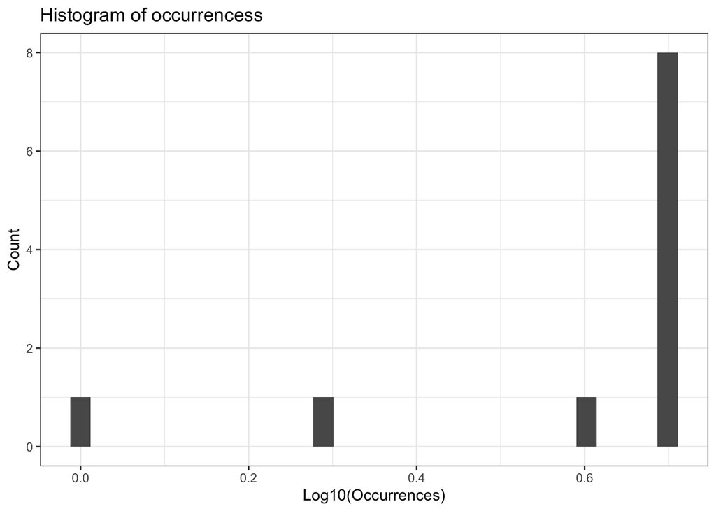

```r
## Visualize histogram of occurrences
plot_1_histogram <- step_10_occurrences_reads %>%
  ggplot() +
  geom_histogram(aes(log10(occurrences_perASV))) +
  ggtitle(label = "Histogram of occurrencess") +
  ylab("Count") +
  xlab("Log10(Occurrences)") + theme_bw()

# save plot
ggsave(
  plot = plot_1_histogram,
  here(config_file$output_path,
        config_file$region,
        "Output_plots",
       "step10_Histogram_of_occurrences.png"),
  device = "png",
  width = 12,
  height = 8,
  units = "in"
)

# view plot:
plot_1_histogram
```

Plot the reads vs occurrences

```r
## Visualize read counts versuses occurrences
plot_2_reads_vs_occ <- step_10_occurrences_reads %>%
  ggplot() +
  geom_point(aes(x = log10(occurrences_perASV), y = log10(tot_reads))) +
  ggtitle(label = "Reads versus Occurrences") +
  ylab("log10(nReads)") +
  xlab("log10(Occurrences)")

ggsave(
  plot = plot_2_reads_vs_occ,
 here(config_file$output_path,
      config_file$region,
      "Output_plots",
       "step10_nReads_versus_Occurrences_across_all_samples.png"),
  device = "png",
  width = 12,
  height = 8,
  units = "in"
)
```

### Step 10.2 Filter by Pattern of Presence (low occurrences)

```r
## Summarize Occurrence Thresholds
step_10_occurrences_reads_classified <- step_10_occurrences_reads %>%
  mutate(., threshold_ASV_occ =
           case_when(
             occurrences_perASV > 1 & occurrences_perASV <= 3 ~ "2", # if only including ASVs in 2 or 3 samples
             occurrences_perASV > 3 & occurrences_perASV <= 10  ~ "4", # if only including ASVs in 4-9 samples
             occurrences_perASV > 10 ~ "11", # if only including ASVs in at least 11 samples
             TRUE ~ "Occurs in 1 sample" # if only including ASVs in 1 sample
    )
  )

# summarise number of reads that would be removed with each filtering threshold:
step_10_reads <- step_10_occurrences_reads_classified %>%
  ungroup() %>%
  mutate(., total = sum(tot_reads)) %>%
  group_by(threshold_ASV_occ, total) %>%
  dplyr::summarise(tot_reads = sum(tot_reads)) %>%
  mutate(., perc_reads = paste0(round(100 * tot_reads / total, 2), "%")) %>%
  dplyr::select(-total)
# and number of ASVs that would be removed with each filtering threshold to number of reads removed:
step_10_counts_reads <- step_10_occurrences_reads_classified %>%
  ungroup() %>%
  dplyr::count(threshold_ASV_occ) %>%
  mutate(., total = sum(n)) %>%
  mutate(per_ASVs = paste0(round(100 * n / total, 2), "%")) %>%
  dplyr::select(-total) %>% left_join(step_10_reads)

# save output as csv:
write_csv(step_10_counts_reads, file = here(config_file$output_path,config_file$region,"Output_csv","step10_PresOfOcc_summary.csv"))
```

Add filtering threshold and save to nested and summary files

```r
### Add to ASV.nested
ASV_nested <- ASV_nested %>%
  mutate(Step10_tibble_occurrence = purrr::map(Step9_singletons_removed, function(.x) {
    .x %>%
      left_join(step_10_occurrences_reads_classified %>% dplyr::select(-c("K","tot_reads"))) %>%
      filter(., occurrences_perASV >= eval(parse(text=print(config_file$step10_occurrence_thresh, quote=F))))
  }))
```

```
## [1] 2
```

```r
### Summary.file
ASV_summary <- ASV_nested %>%
  dplyr::mutate(Miseq_region,
    Summary_1 = purrr::map(
      Step10_tibble_occurrence,
      ~ how.many(ASVtable = ., round = "10_Occurrences")), .keep="none"
  ) %>%
  left_join(ASV_summary) %>%
  mutate(Summary = map2(Summary, Summary_1, bind_rows)) %>%
  dplyr::select(-Summary_1)

ASV_summary$Summary[[1]]
```

```
## # A tibble: 18 × 3
##    Stage                       Stat     number
##    <chr>                       <chr>     <dbl>
##  1 Step_Merged                 nsamples      5
##  2 Step_Merged                 nHashes      11
##  3 Step_Merged                 nReads   125348
##  4 Step_6_Low_Read_Depth       nsamples      5
##  5 Step_6_Low_Read_Depth       nHashes      11
##  6 Step_6_Low_Read_Depth       nReads   125348
##  7 Step_7_Low_div_pass         nsamples      5
##  8 Step_7_Low_div_pass         nHashes      11
##  9 Step_7_Low_div_pass         nReads   125348
## 10 Step_8_Rep_outliers_removed nsamples      5
## 11 Step_8_Rep_outliers_removed nHashes      11
## 12 Step_8_Rep_outliers_removed nReads   125348
## 13 Step_9_singletons_removed   nsamples      5
## 14 Step_9_singletons_removed   nHashes      11
## 15 Step_9_singletons_removed   nReads   125348
## 16 Step_10_Occurrences         nsamples      5
## 17 Step_10_Occurrences         nHashes      10
## 18 Step_10_Occurrences         nReads    95348
```

## Step 11: Remove n-ton (user defined ASV min) [ASV filtering]

### Pull out Sample Read Depth

n-ton filtering

```r
if (config_file$step11_filt_option=="n-ton") {
  message("Step 11: ASV n-ton filtering")
    ## Calculate occurence, total read count, and total sample count
    step_11_nton_filt <- ASV_nested %>%
      dplyr::select(Step10_tibble_occurrence) %>%
      unnest(Step10_tibble_occurrence) %>% # This stage is a long table
      ungroup() %>%
      group_by(seq_id) %>% # group by hash (merged across projects)
      mutate(TotalReadsperASV = sum(reads)) %>% # sum reads per ASV
            mutate(threshold_nton_filt=case_when( # add levels to n-ton filtering
              TotalReadsperASV > 1 &  TotalReadsperASV < 10 ~ "2",
              TotalReadsperASV >= 10 ~ "10",
              TRUE ~ "Singleton")) %>% # more of a sanity check, this should not be true!
            ungroup() %>%
      group_by(threshold_nton_filt) %>%
      mutate(tot_reads=sum(reads))

    # summarise number of reads that would be removed with each filtering threshold:
    step_11_reads <- step_11_nton_filt %>%
      ungroup() %>%
      dplyr::select(threshold_nton_filt, tot_reads) %>% unique() %>%
      dplyr::mutate(total = sum(tot_reads)) %>%
      mutate(., perc_reads = paste0(round(100 * tot_reads / total, 2), "%")) %>%
      dplyr::select(-total)

    # and number of ASVs that would be removed with each filtering threshold to number of reads removed:
    step_11_counts_reads <- step_11_nton_filt %>%
      ungroup() %>%
      dplyr::select(threshold_nton_filt, seq_id) %>% unique() %>%
      dplyr::count(threshold_nton_filt) %>%
      mutate(., total = sum(n)) %>%
      mutate(per_ASVs = paste0(round(100 * n / total, 2), "%")) %>%
      dplyr::select(-total) %>% left_join(step_11_reads)

    # save output as csv:
    write_csv(step_11_counts_reads,
              file = here(config_file$output_path,config_file$region,"Output_csv","step11_nton_summary.csv"))
} else {
  message("Skip - Step 11: ASV n-ton filtering")
}
```

Percent total reads ASV filtering

```r
if (config_file$step11_filt_option=="perc_reads") {
  message("Step 11: ASV % total reads filtering")
    ## Calculate occurence, total read count, and total sample count
    step_11_percTot_filt <- ASV_nested %>%
      dplyr::select(Step10_tibble_occurrence) %>%
      unnest(Step10_tibble_occurrence) %>% # This stage is a long table
      ungroup() %>%
      dplyr::select(seq_id, sample, reads) %>%
      unique() %>%
      # pivot_wider(names_from = sample, values_from = reads) %>%
      group_by(seq_id) %>%
      summarise(TotalReadsperASV=sum(reads)) %>%
      mutate(Total_reads=sum(TotalReadsperASV),
             perc_total=TotalReadsperASV/Total_reads) %>%
      arrange(desc(perc_total))

    # save output as csv:
    write_csv(step_11_percTot_filt, file =
                here(config_file$output_path,config_file$region,"Output_csv","step11_ASV_perc_summary.csv"))
} else {
  message("Skip - Step 11: ASV % total reads filtering")
}
```

#### Add to ASV nested and summary:

```r
if (config_file$step11_filt_option=="n-ton") {
  message("Step 11: ASV n-ton filtering")
  ### Add to ASV.nested
  ASV_nested <- ASV_nested %>%
    mutate(Step11_ASV_filt = purrr::map(Step10_tibble_occurrence, function(.x) {
      .x %>%
        left_join(step_11_nton_filt %>% dplyr::select(-c("tot_reads"))) %>%
        filter(., TotalReadsperASV >= eval(parse(text=print(config_file$step11_nton_thresh, quote=F))))
    }))
} else {
  message("Step 11: ASV % Total reads filtering")
  ### Add to ASV.nested
  ASV_nested <- ASV_nested %>%
    mutate(Step11_ASV_filt = purrr::map(Step10_tibble_occurrence, function(.x) {
      .x %>%
        left_join(step_11_percTot_filt %>% dplyr::select(-c("TotalReadsperASV","Total_reads"))) %>%
        filter(., perc_total >= eval(parse(text=print(config_file$step11_perc_reads, quote=F))))
    }))

}
```

```
## [1] 1
```

Add to summary file:

```r
### Summary.file
ASV_summary <- ASV_nested %>%
  dplyr::mutate(Miseq_region,
    Summary_1 = purrr::map(
      Step11_ASV_filt,
      ~ how.many(ASVtable = ., round = "11_ASV_filt")), .keep="none"
  ) %>%
  left_join(ASV_summary) %>%
  mutate(Summary = map2(Summary, Summary_1, bind_rows)) %>%
  dplyr::select(-Summary_1)

ASV_summary$Summary[[1]]
```

```
## # A tibble: 21 × 3
##    Stage                       Stat     number
##    <chr>                       <chr>     <dbl>
##  1 Step_Merged                 nsamples      5
##  2 Step_Merged                 nHashes      11
##  3 Step_Merged                 nReads   125348
##  4 Step_6_Low_Read_Depth       nsamples      5
##  5 Step_6_Low_Read_Depth       nHashes      11
##  6 Step_6_Low_Read_Depth       nReads   125348
##  7 Step_7_Low_div_pass         nsamples      5
##  8 Step_7_Low_div_pass         nHashes      11
##  9 Step_7_Low_div_pass         nReads   125348
## 10 Step_8_Rep_outliers_removed nsamples      5
## # ℹ 11 more rows
```

## Step 12: (Optional) Removing low complexity x% of sample comprised of one ASV [Sample filtering].

Filter samples by low complexity user defined value, default it 1 in config_file which won’t remove any samples for this step.

```r
## Identify samples that have greater than 99% of ASVs
asv_prop <- ASV_nested %>%
    dplyr::select(Step11_ASV_filt) %>% # pos contaminants removed tibble
    unnest(Step11_ASV_filt) %>% # unnest tibble to work with
    dplyr::select(seq_id, reads, sample) %>% # select only necessary columns
  distinct() %>%
    pivot_wider( # pivot wider so read counts are now below each sample name
      names_from = sample,
      values_from = reads,
      values_fill = list(reads = 0)
    ) %>%
  # calculate the porportion each ASV makes of the the total reads per sample
  mutate(across(-c("seq_id"), ~ .x/sum(.x))) %>%
  pivot_longer(cols = starts_with("sample"),
               names_to = "sample",
               values_to = "prop_reads") %>%
  filter(prop_reads > config_file$step12_prop) # identify samples that have ASVs that make up greater than 99% of reads.

## Filter out samples with extreme low diversity:
ASV_nested <- ASV_nested %>%
  mutate(step_12_low_div_pass =
           purrr::map(Step11_ASV_filt,
                      ~ filter(., !sample %in% asv_prop$sample))
  )

### Summary.file
ASV_summary <- ASV_nested %>%
  dplyr::mutate(Miseq_region,
    Summary_1 = purrr::map(
      step_12_low_div_pass,
      ~ how.many(ASVtable = ., round = "12_low_sample_complexity")), .keep="none"
  ) %>%
  left_join(ASV_summary) %>%
  mutate(Summary = map2(Summary, Summary_1, bind_rows)) %>%
  dplyr::select(-Summary_1)

ASV_summary$Summary[[1]]
```

```
## # A tibble: 24 × 3
##    Stage                       Stat     number
##    <chr>                       <chr>     <dbl>
##  1 Step_Merged                 nsamples      5
##  2 Step_Merged                 nHashes      11
##  3 Step_Merged                 nReads   125348
##  4 Step_6_Low_Read_Depth       nsamples      5
##  5 Step_6_Low_Read_Depth       nHashes      11
##  6 Step_6_Low_Read_Depth       nReads   125348
##  7 Step_7_Low_div_pass         nsamples      5
##  8 Step_7_Low_div_pass         nHashes      11
##  9 Step_7_Low_div_pass         nReads   125348
## 10 Step_8_Rep_outliers_removed nsamples      5
## # ℹ 14 more rows
```

## Step 13: Remove unknowns (optional) [ASV filtering]

```r
### Filter by Taxonomic Paths
# This list can be expanded upon additional work to identify known contaminants within OME PMEL samples
if (file.exists(config_file$step13_unknown_characters_to_remove_path)) {
  step13_species_to_remove <- read.csv(here(config_file$step13_unknown_characters_to_remove_path))$Domain

} else {
  step13_species_to_remove <- c("Unknown","unknown","unclassified","Unclassified","Environmental Unknown","Unassigned","NA")

}
```

If step13_remove=TRUE in config file, remove seq_id with unknown Domains, if not keep everything.

```r
## Identify ASVs (seq_id) that have unknown Domains
step13_species_to_remove <- ASV_nested %>%
    dplyr::select(step_12_low_div_pass) %>% # pos contaminants removed tibble
    unnest(step_12_low_div_pass) %>% # unnest tibble to work with
    dplyr::select(seq_id, sum.taxonomy, sample) %>% # select only necessary columns
  separate_wider_delim( # Separate out sample id to get cruise id
    sum.taxonomy,
    delim = ";",
    names = "Domain", # separating columns
    too_few = "align_end",
    too_many = "drop",
    cols_remove = FALSE
  ) %>%
  filter(Domain %in% step13_species_to_remove | is.na(Domain))

## Filter out samples with unknowns
if (config_file$step13_remove==TRUE) {
  message("Step 13: ASVs with unknown Domains removed")
  ASV_nested <- ASV_nested %>%
    mutate(step_13_unknown_removed =
             purrr::map(step_12_low_div_pass,
                        ~ filter(., !seq_id %in% step13_species_to_remove$seq_id))
  )

  } else { # If there isn't a positive control output message
    message("Step 13: samples not filtered out by taxonomy")
    ASV_nested <- ASV_nested %>%
      mutate(step_13_unknown_removed = step_12_low_div_pass)

  }

### Summary_file
ASV_summary <- ASV_nested %>%
  dplyr::mutate(Miseq_region,
    Summary_1 = purrr::map(
      step_13_unknown_removed,
      ~ how.many(ASVtable = ., round = "13_unk_removed")), .keep="none"
  ) %>%
  left_join(ASV_summary) %>%
  mutate(Summary = map2(Summary, Summary_1, bind_rows)) %>%
  dplyr::select(-Summary_1)

ASV_summary$Summary[[1]]
```

```
## # A tibble: 27 × 3
##    Stage                       Stat     number
##    <chr>                       <chr>     <dbl>
##  1 Step_Merged                 nsamples      5
##  2 Step_Merged                 nHashes      11
##  3 Step_Merged                 nReads   125348
##  4 Step_6_Low_Read_Depth       nsamples      5
##  5 Step_6_Low_Read_Depth       nHashes      11
##  6 Step_6_Low_Read_Depth       nReads   125348
##  7 Step_7_Low_div_pass         nsamples      5
##  8 Step_7_Low_div_pass         nHashes      11
##  9 Step_7_Low_div_pass         nReads   125348
## 10 Step_8_Rep_outliers_removed nsamples      5
## # ℹ 17 more rows
```

## Step 14: Low sample depth pass/discard PCR replicates of low depth (aka 40k or confidence %) [Sample Filtering]

If step14_depth_filt is 0 in config file, this step will be skipped if greater than 0 all reads below the cutoff will be filtered out.

### Pull sample read depth out:

```r
# Get the summary of total ASVs per region per sample
all_reps <- ASV_nested %>%
  dplyr::select(Miseq_region, step_13_unknown_removed) %>%
  unnest(step_13_unknown_removed) %>%
  group_by(Miseq_region, sample) %>%
  dplyr::summarise(tot_step14 = sum(reads)) %>%
  arrange(desc(tot_step14)) %>% ungroup()

# Calculate reads per sample:
reads_per_sample <- all_reps %>%
  filter(., tot_step14 > 100) %>%
  pull(tot_step14)

names(reads_per_sample) <- all_reps %>%
  filter(., tot_step14 > 100) %>%
  pull(sample)
```

#### Visualize Read Counts Across Samples before Step 14 filtering:

```r
plot_step13 <- ggplot(all_reps, aes(x = tot_step14)) +
  geom_histogram(binwidth=1000, fill="darkgrey", color="black") +
  geom_vline(xintercept = 10000, color="red") +
  geom_vline(xintercept = 1000, color="red", linetype = "dashed") +
  theme_bw()

ggsave(
  plot = plot_step13,
  here(config_file$output_path,config_file$region,"Output_plots","step13_Sample_Read_Depth.png"),
  device = "png",
  width = 12,
  height = 8,
  units = "in"
)
```

```r
### Fit Normal Distribution
fit <- tryCatch({
  message("Attempting MLE estimation...")
  fitdist(
    reads_per_sample,
    "gamma",
    lower = c(0, 0),
    start = list(scale = 1, shape = 1)
  )
}, error = function(e) {
  message("MLE failed with error: ", e$message)
  message("Retrying with method = 'mme'...")
  # Return the MME fit instead
  fitdist(
    reads_per_sample,
    "gamma",
    method = "mme",
    lower = c(0, 0),
    start = list(scale = 1, shape = 1)
  )
})

all_reps <- all_reps %>%
  mutate(prob = pgamma(
    tot_step14,
    shape = fit$estimate[[2]],
    scale = fit$estimate[[1]],
    lower.tail = TRUE,
    log.p = FALSE
  )) %>% ungroup()

### Remove Outlier Samples
outliers <- all_reps %>%
  filter(prob < config_file$step14_low_dist_probability_cutoff)

## what would be removed if used probability:
all_reps %>%
  mutate(
    .,
    Step14_read_depth_flag = if_else(
      prob < config_file$step14_low_dist_probability_cutoff,
      # changed to 0.05 to save the two samples
      "Warning Low Read Depth",
      "Ok"
    )
  ) %>%
  filter(., Step14_read_depth_flag != "Ok")
```

```
## # A tibble: 0 × 5
## # ℹ 5 variables: Miseq_region <chr>, sample <chr>, tot_step14 <dbl>,
## #   prob <dbl>, Step14_read_depth_flag <chr>
```

```r
## Add to ASV_nested
ASV_nested <- ASV_nested %>%
  mutate(step_14_low_depth_pass = purrr::map(step_13_unknown_removed, ~ filter(., !sample %in% outliers$sample) %>%
        left_join(all_reps) %>%
          ungroup() %>%
        dplyr::select(-c("Miseq_region")) %>%
        mutate(Step14_read_depth_flag = if_else(
            prob < config_file$step14_low_dist_probability_cutoff,
            "Warning Low Read Depth",
            "Ok"))
    )
  )
```

### Add to summary file

```r
### Summary_file
ASV_summary <- ASV_nested %>%
  dplyr::mutate(Miseq_region,
    Summary_1 = purrr::map(
      step_14_low_depth_pass,
      ~ how.many(ASVtable = ., round = "14_low_read_depth")), .keep="none"
  ) %>%
  left_join(ASV_summary) %>%
  mutate(Summary = map2(Summary, Summary_1, bind_rows)) %>%
  dplyr::select(-Summary_1)

kable(tail(ASV_summary$Summary, 30))
```

| Stage | Stat | number |
| --- | --- | --- |
| Step_Merged | nsamples | 5 |
| Step_Merged | nHashes | 11 |
| Step_Merged | nReads | 125348 |
| Step_6_Low_Read_Depth | nsamples | 5 |
| Step_6_Low_Read_Depth | nHashes | 11 |
| Step_6_Low_Read_Depth | nReads | 125348 |
| Step_7_Low_div_pass | nsamples | 5 |
| Step_7_Low_div_pass | nHashes | 11 |
| Step_7_Low_div_pass | nReads | 125348 |
| Step_8_Rep_outliers_removed | nsamples | 5 |
| Step_8_Rep_outliers_removed | nHashes | 11 |
| Step_8_Rep_outliers_removed | nReads | 125348 |
| Step_9_singletons_removed | nsamples | 5 |
| Step_9_singletons_removed | nHashes | 11 |
| Step_9_singletons_removed | nReads | 125348 |
| Step_10_Occurrences | nsamples | 5 |
| Step_10_Occurrences | nHashes | 10 |
| Step_10_Occurrences | nReads | 95348 |
| Step_11_ASV_filt | nsamples | 5 |
| Step_11_ASV_filt | nHashes | 10 |
| Step_11_ASV_filt | nReads | 95348 |
| Step_12_low_sample_complexity | nsamples | 5 |
| Step_12_low_sample_complexity | nHashes | 10 |
| Step_12_low_sample_complexity | nReads | 95348 |
| Step_13_unk_removed | nsamples | 5 |
| Step_13_unk_removed | nHashes | 10 |
| Step_13_unk_removed | nReads | 95348 |
| Step_14_low_read_depth | nsamples | 5 |
| Step_14_low_read_depth | nHashes | 10 |
| Step_14_low_read_depth | nReads | 95348 |

## Save final nested files:

```r
# Save summary and nested data
saveRDS(ASV_nested, file = here(config_file$output_path,
                                config_file$region,
                                "Output_R","ASV_nested_final_partIV.RDS"))
saveRDS(ASV_summary, file = here(config_file$output_path,
                                config_file$region,
                                 "Output_R","ASV_summary_final_partIV.RDS"))
```

## Save final format of decontaminated dataframe:

### Save final output file of all data:

```r
# final filtered dataframe:
decontam_final_output <- ASV_nested$step_14_low_depth_pass %>% as.data.frame()

# save dataframe as csv:
write_csv(decontam_final_output, here(config_file$output_path,
                                            config_file$region,
                                           "Output_csv",
                                           "Decontam_final_output.csv"))
```

### Format final data as asv, taxonomy, metadata, and fasta files

- ASV table of reads
- metadata file
- taxonomy table
- fasta file

```r
# ASV table:
partIV_ASV_final_output <- decontam_final_output %>% dplyr::select("seq_id","sample","reads") %>%
  distinct() %>%
  pivot_wider( # pivot wider so read counts are now below each sample name
      names_from = sample,
      values_from = reads,
      values_fill = list(reads = 0)
    )

## metadata file:
partIV_meta_final_output <- read_csv(here(config_file$output_path,
                                          config_file$region,
                                          "Output_csv","meta_final_partII.csv")) %>%
                            filter(samp_name %in% decontam_final_output$sample) %>%
                            distinct()

# taxonomy file:
partIV_taxa_final_output<-decontam_final_output %>% dplyr::select("seq_id","sum.taxonomy") %>% distinct()

## fasta file:
# load merged file for sequences for list of seq_id and sequences:
merged_seqs<-read_csv(here(config_file$output_path,
                                                config_file$region,
                                                "Output_csv","partII_merged.csv")) %>%
                      dplyr::select(seq_id,sequence) %>% distinct()
# keep only final seq_id's after decontam processing
decontam_final_seq_ids <- decontam_final_output %>%
                          dplyr::select(seq_id) %>% unique()
# filter seq_id's:
merged_seqs_filt <- merged_seqs %>%
                      filter(seq_id %in% decontam_final_seq_ids$seq_id)
# convert to fasta format:
merged_seqs_fasta <- DNAStringSet(merged_seqs_filt$sequence)
names(merged_seqs_fasta) <- merged_seqs_filt$seq_id
```

### Save final data as asv, taxonomy, metadata, and fasta files

- ASV table of reads
- metadata file
- taxonomy table
- fasta file

```r
# save asv tables
write_csv(partIV_ASV_final_output, file = here(config_file$output_path,
                                                config_file$region,
                                               "Output_csv","Decontam_final_asv_table.csv"))
# save taxonomy table
write_csv(partIV_taxa_final_output, file = here(config_file$output_path,
                                                config_file$region,
                                                "Output_csv","Decontam_final_taxonomy_table.csv"))
# save metadata file
write_csv(partIV_meta_final_output, file = here(config_file$output_path,
                                                config_file$region,
                                                "Output_csv","Decontam_final_metadata.csv"))

# save fasta file:
writeXStringSet(merged_seqs_fasta, file = here(config_file$output_path,
                                                config_file$region,
                                                "Output_csv","Decontam_final_seqs.fasta"))
```

### Including other taxonomy:

```r
if (!is.null(config_file$add_taxonomy)) {
    # load pr2 data: (from Convert_taxa.R)
    pr2_taxa_across_runs <- merge_taxa_output(config_file_name, tax_file_ext=config_file$add_taxa_file_extension)

    # keep only ASVs in final dataset:
    pr2_taxa_across_runs_filt <- pr2_taxa_across_runs %>% filter(seq_id %in% partIV_ASV_final_output$seq_id)

    # save final taxa output:
    saveRDS(pr2_taxa_across_runs_filt, file = here(config_file$output_path,
                                                    config_file$region,
                                                    "Output_R",paste0("Decontam_",config_file$add_taxonomy, "_taxa.RDS")))

    # choose best option if taxonomies don't match  (from merging_functions.R)
    ## rules for this:
    ### 1. if confidence higher for one ASV compared to another choose that ASV.
    ### 2. if confidence the same (down to 2nd decimal), choose taxonomy with lower id'd taxonomy, if they match at higher taxonomy, if not reduce down to lowest matching taxonomy.
    pr2_taxa_final<-choose_best_taxa(pr2_taxa_across_runs_filt)
    # save final taxonomy
    write_csv(pr2_taxa_final, file = here(config_file$output_path,
                                                    config_file$region,
                                                    "Output_csv",paste0("Decontam_final_taxonomy_table_",config_file$add_taxonomy, ".csv")))
} else {
  message("No additional taxonomy to add.")
}
```